# GIS in R - Rasters and Points

M. Toomey

2022-10-18

A wide range of tools are available in `R` to work geographic information system (GIS) data. In this lesson we will

1. learn how to import, plot, and modify:
- Raster files - pixelated or gridded data where each cell is a value at some point on the earths surface.
- Shapefiles - vectors of features, points, lines, polygons with specific attributes.
2. We will use publicly available data to model our own personal climate envelope.Essentially, we will pretend we are each a species and create our own personal “species” distribution model.

This will involve:

1. Loading climate rasters.
2. Selecting points from places you’ve lived and/or traveled to.
3. Extracting climate data from these points.
4. Stacking the relevant climate rasters
5. Training a “species” distribution model.
6. Plotting your climate envelope.
7. Comparing your envelope to global climates.

### Preliminaries

For this exercise we will need to install and load the following packages:

```r
# install.packages(c("sp","rgdal","raster","rgeos","geosphere","dismo"))
```

```r
library(sp) # classes for vector data (polygons, points, lines)
library(rgdal) # basic operations for spatial data
library(raster) # handles rasters
library(rgeos) # methods for vector files
library(geosphere) # more methods for vector files
library(dismo) # species distribution modeling tools
```

### Prepare your project folder

GIS projects often involve several different classes of data and multiple files in a single analysis. To avoid confusion, let’s create a working folder `GIS_lesson` with four subfolders:

- `My_Climate_Sapce`
- `My_loacations`
- `WORLDCLIM_Rasters`
- `Country_Shapefiles`

You can simply do this in the file browser on your computer.

### Load Climate Data Rasters

We will use data available from worldclim.org to model the climate envelope and specifically 19 standard climatic variables recorded 1970-2000:

https://geodata.ucdavis.edu/climate/worldclim/2_1/base/wc2.1_10m_bio.zip

Download this folder, unzip it, and move the files into your `WORLDCLIM_Rasters` folder. You should have a set of 19 .tif files. Each raster corresponds to a different climatic variable and you can learn more about each here:

https://www.worldclim.org/data/bioclim.html

Let’s take a look at one of these rasters:

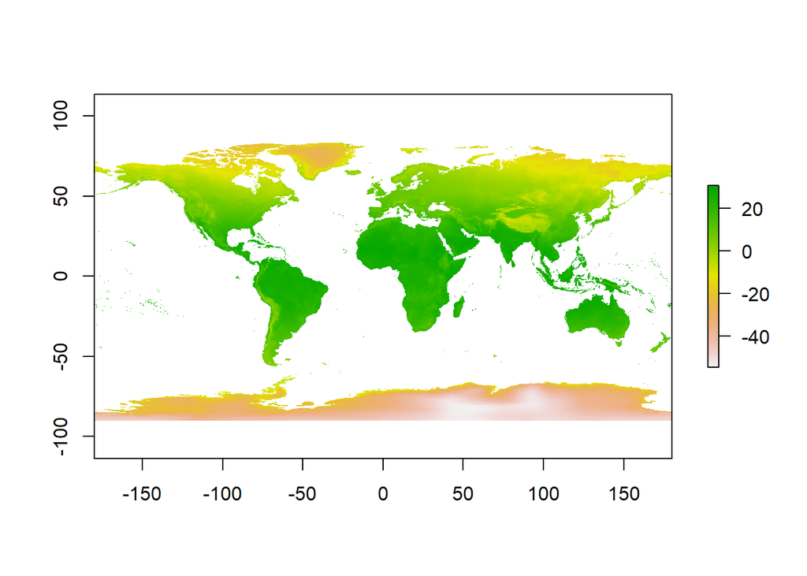

```r
#load a raster
bio1<- raster("WORLDCLIM_Rasters/wc2.1_10m_bio_1.tif")
plot(bio1)
```

`bio1` is the mean temperature of the earth from 1970-2000. The units are degrees Celsius. Let’s look at the metadata:

```r
bio1
```

```
## class      : RasterLayer
## dimensions : 1080, 2160, 2332800  (nrow, ncol, ncell)
## resolution : 0.1666667, 0.1666667  (x, y)
## extent     : -180, 180, -90, 90  (xmin, xmax, ymin, ymax)
## crs        : +proj=longlat +datum=WGS84 +no_defs
## source     : wc2.1_10m_bio_1.tif
## names      : wc2.1_10m_bio_1
## values     : -54.72435, 30.98764  (min, max)
```

Here’s what you will see:

Line 1, `class`: `bio1` is a raster.

Line 2, `dimensions`: Raster dimensions.

Line 4, `extent`: This is the “bounding box” of the raster.

Line 5, `crs`: This string represents the WGS84 coordinate reference system. It tells R how to draw the raster and what units for cell size.

Line 6, `data source`: If the raster is in memory or a file.

Line 7, `names`: The name of the raster… you can change this with `names(bio01) <- 'meanTemp'`.

Line 8, `values`: The min and max values of the raster

You can do math on a raster just like any variable in R. Let’s convert to Celsius to Fahrenheit.

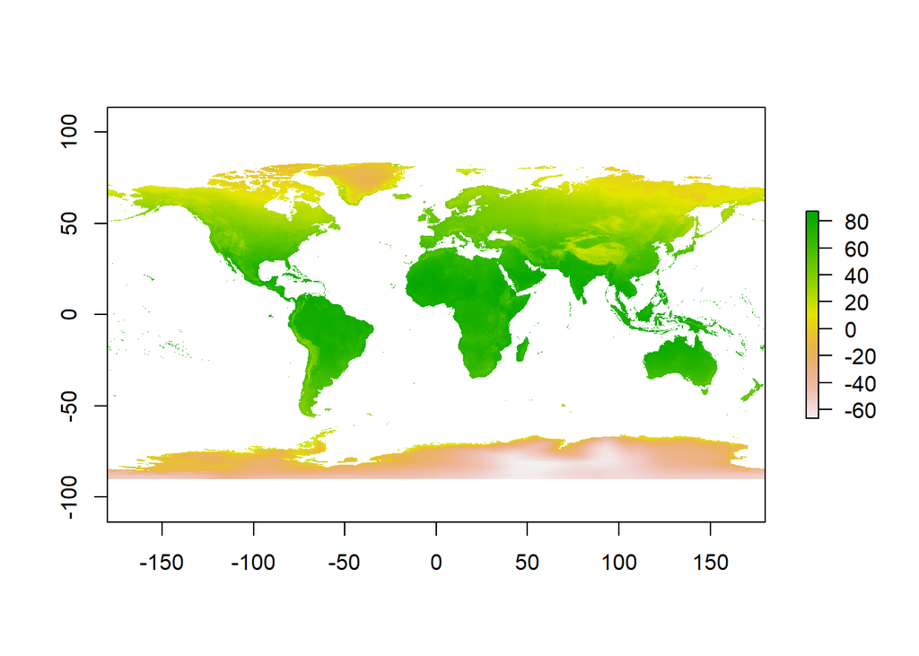

```r
bio1_f <- bio1 * (9/5)+32
plot(bio1_f)
```

If we want to work with multiple rasters that have the same extent and resolution we can create a stack

```r
clim_stack <- stack(list.files("WORLDCLIM_Rasters", full.names = TRUE, pattern = ".tif"))
```

Let’s look at the stack

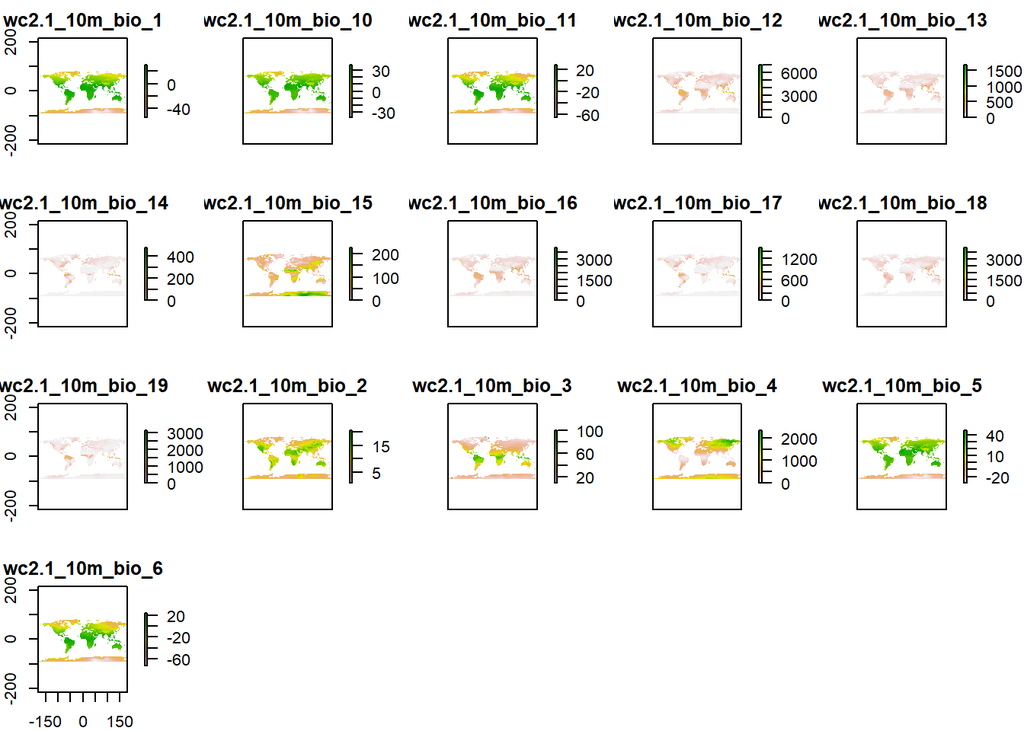

```r
plot(clim_stack, nc = 5) # nc plots five columns of the 19 rasters
```

```r
clim_stack
```

```
## class      : RasterStack
## dimensions : 1080, 2160, 2332800, 19  (nrow, ncol, ncell, nlayers)
## resolution : 0.1666667, 0.1666667  (x, y)
## extent     : -180, 180, -90, 90  (xmin, xmax, ymin, ymax)
## crs        : +proj=longlat +datum=WGS84 +no_defs
## names      : wc2.1_10m_bio_1, wc2.1_10m_bio_10, wc2.1_10m_bio_11, wc2.1_10m_bio_12, wc2.1_10m_bio_13, wc2.1_10m_bio_14, wc2.1_10m_bio_15, wc2.1_10m_bio_16, wc2.1_10m_bio_17, wc2.1_10m_bio_18, wc2.1_10m_bio_19, wc2.1_10m_bio_2, wc2.1_10m_bio_3, wc2.1_10m_bio_4, wc2.1_10m_bio_5, ...
## min values :      -54.724354,       -37.781418,       -66.311249,         0.000000,         0.000000,         0.000000,         0.000000,         0.000000,         0.000000,         0.000000,         0.000000,        1.000000,        9.131122,        0.000000,      -29.686001, ...
## max values :        30.98764,         38.21617,         29.15299,      11191.00000,       2381.00000,        484.00000,        229.00169,       5284.00000,       1507.00000,       5282.00000,       4467.00000,        21.14754,       100.00000,      2363.84595,        48.08275, ...
```

For the remainder of the exercise, select a subset (3-5) of the climate variables that are particularly interesting or important to you and make your own raster stack.

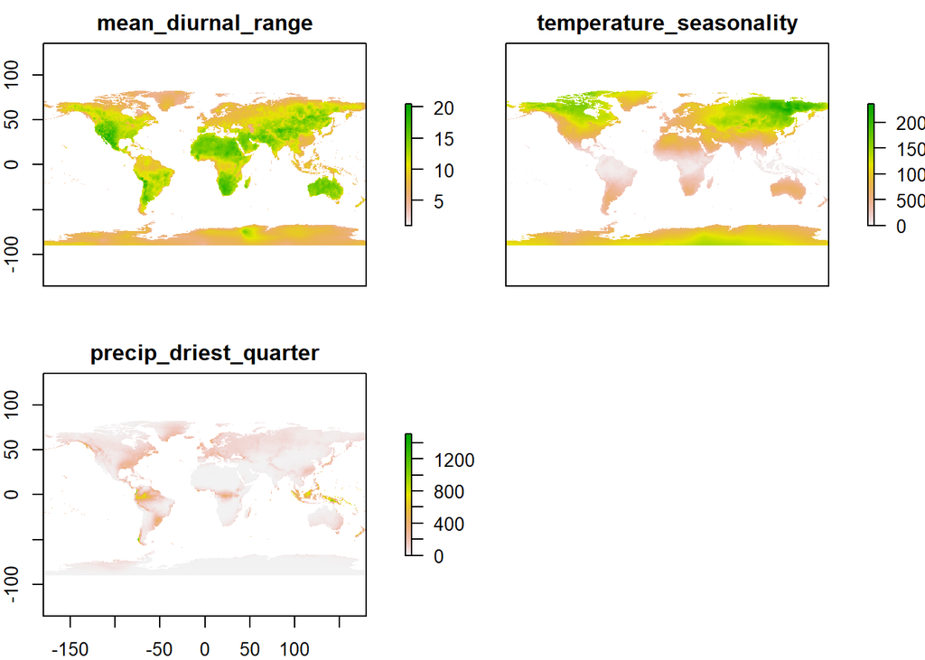

```r
my_clim_stack <- stack(
  raster('WORLDCLIM_Rasters/wc2.1_10m_bio_2.tif'),
  raster('WORLDCLIM_Rasters/wc2.1_10m_bio_4.tif'),
  raster('WORLDCLIM_Rasters/wc2.1_10m_bio_17.tif')
)
#Look up the variable on https://www.worldclim.org/data/bioclim.html and rename the variable with a more descriptive name.
names(my_clim_stack) <- c("mean_diurnal_range", "temperature_seasonality", "precip_driest_quarter")

plot(my_clim_stack)
```

Are my variables climate correlated with one another?

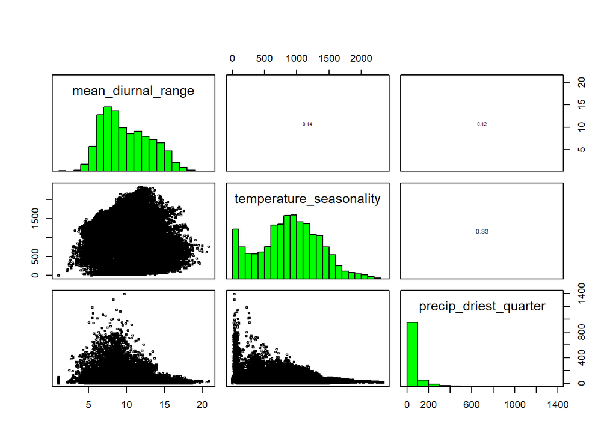

```r
pairs(my_clim_stack) #pairs is a base R function that plots univariate distribution and bivariate relationships
```